# **UN INCONTRO DI BOX OFFICE**

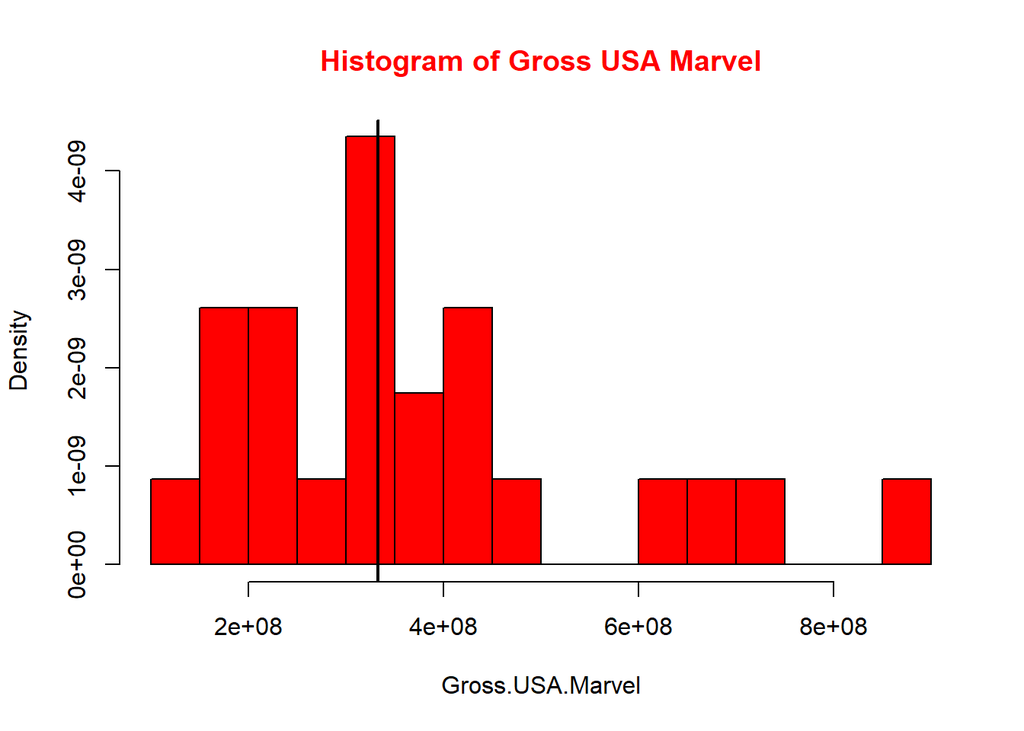

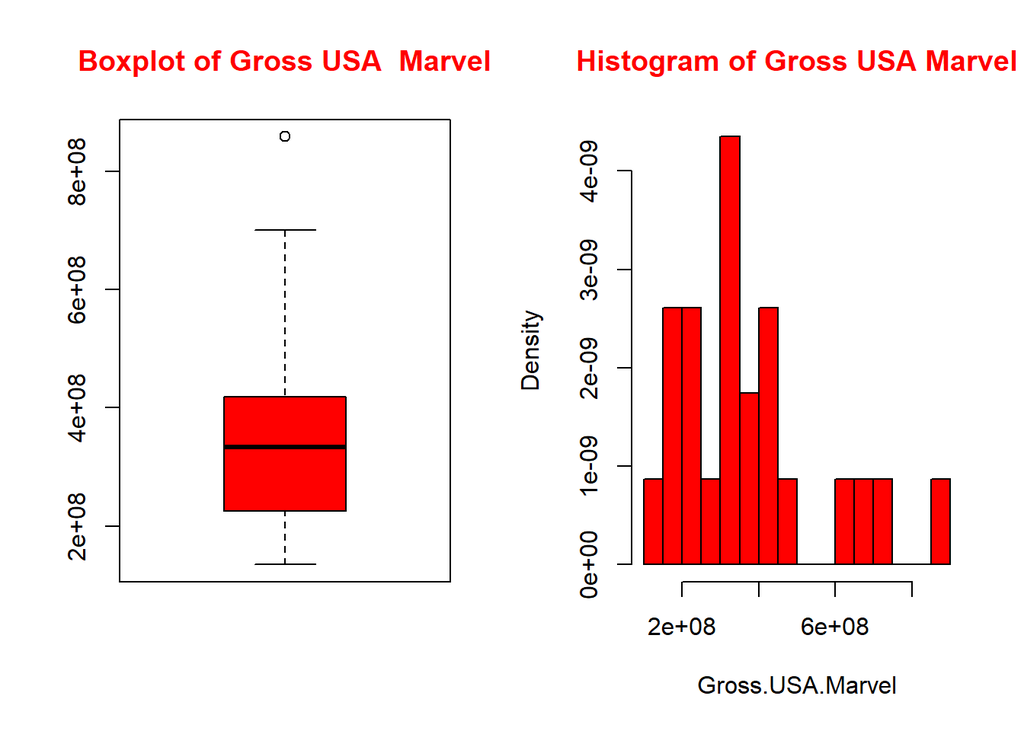

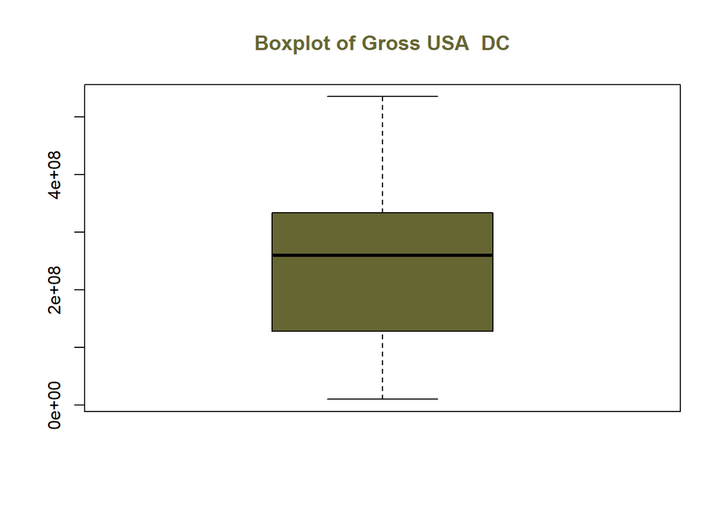

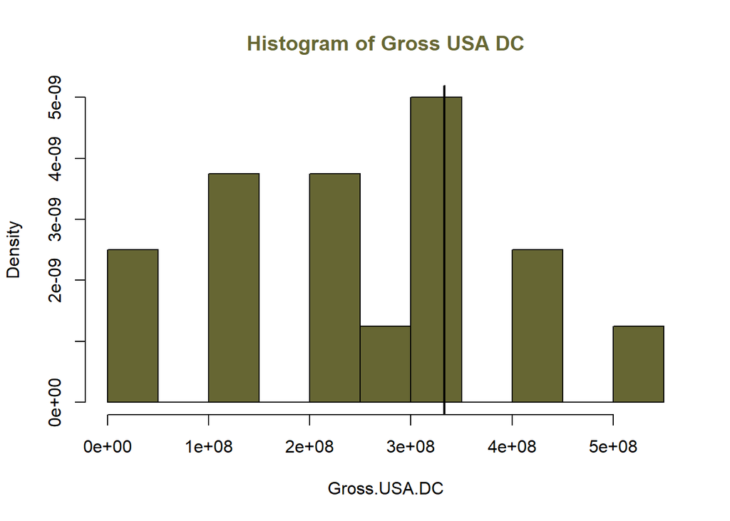

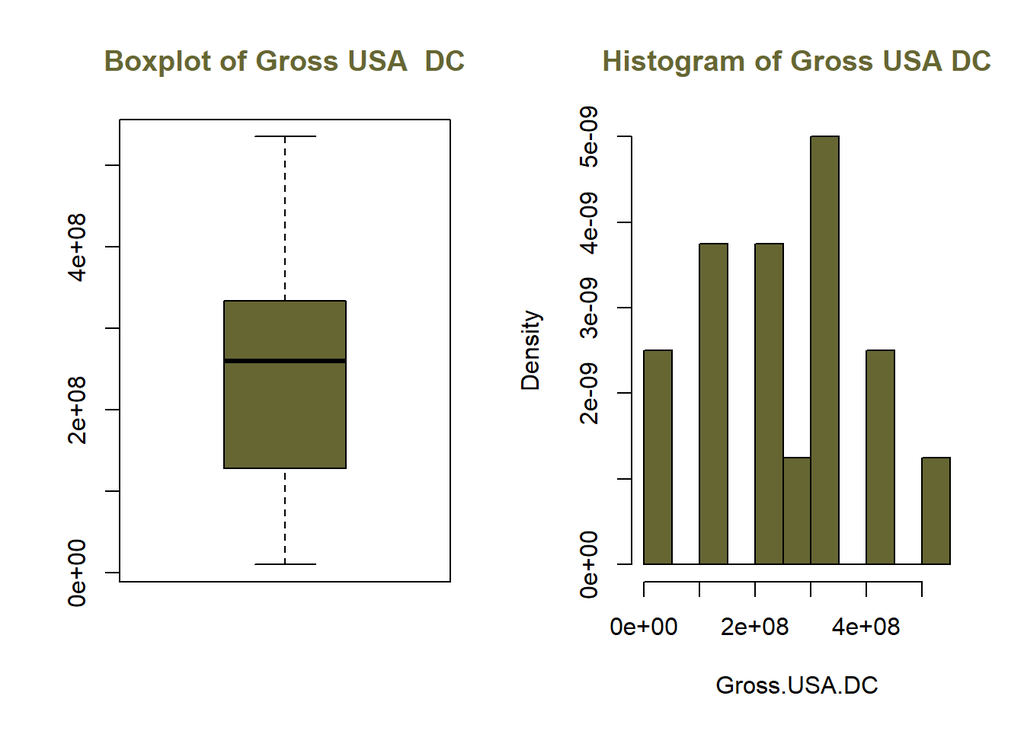

#### *E’ difficile confrontare boxplot e istogrammi che si distribuiscono su scale differenti.*

### *E’ necessario affiancare i boxplot della variabile Gross.USA di Marvel e DC, in modo da valutare la distribuzione avendo come riferimento la stessa scala*

```
$DC
     Min.   1st Qu.    Median      Mean   3rd Qu.      Max.
 10547117 134429035 260034906 253868671 333668887 535234033

$Marvel
     Min.   1st Qu.    Median      Mean   3rd Qu.      Max.
134806913 224645330 333176600 371542272 417921916 858373000
```

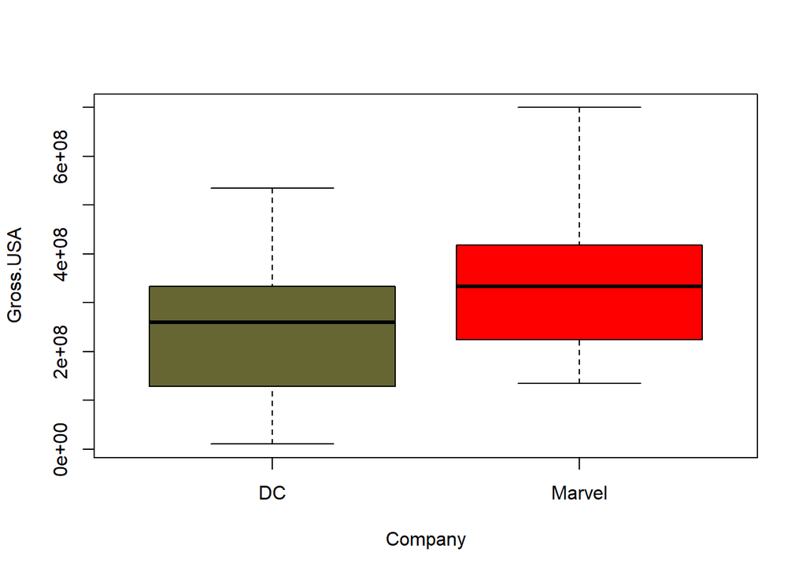

#### *Noto che le osservazioni della variabile Gross.USA si distribuiscono in maniera differente:*

#### -I minimi ed i massimi dei due boxplot presentano disguaglianza:

> Le sservazioni di questa variabile seguono quelle della variabile precedentemente analizzata: il massimo valore della variabile Gross.USA relativa alla company Marvel è maggiore rispetto a quello DC. Il minimo valore ,invece, appartiene sempre ad un film DC.

#### -Il primo quartile ed il terzo presentano una netta disparità:

> La maggior parte delle osservazioni Marvel ha ottenuto maggior Gross negli USA rispetto a quelle DC.

### *Affianco i boxplot della variabile Gross.USA di Marvel e DC e della variabile Opening.weeked.USA di Marvel e DC*

```
$DC
     Min.   1st Qu.    Median      Mean   3rd Qu.      Max.
  5379365  53014501  80857880  86378724 120885084 166007347

$Marvel
     Min.   1st Qu.    Median      Mean   3rd Qu.      Max.
 55414050  85398076 117027503 135096585 176641864 357115007
```

```
$DC
     Min.   1st Qu.    Median      Mean   3rd Qu.      Max.
 10547117 134429035 260034906 253868671 333668887 535234033

$Marvel
     Min.   1st Qu.    Median      Mean   3rd Qu.      Max.
134806913 224645330 333176600 371542272 417921916 858373000
```

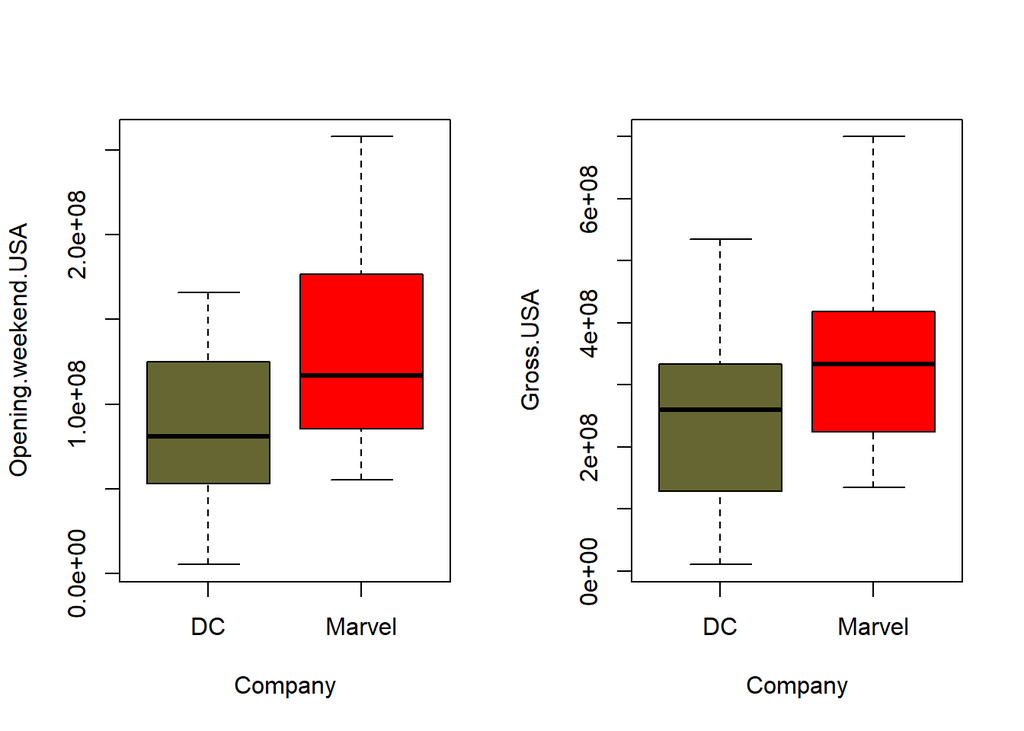

### *Creo un istorgamma che metta in relazione la variabile Gross.USA e la variabile Company*

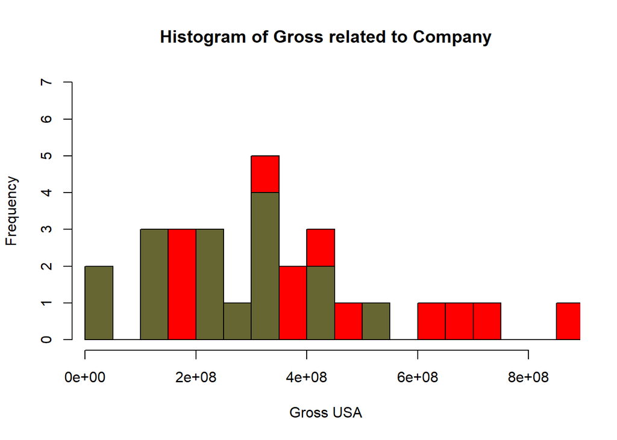

### *Misuro quindi la connessione che c’è tra l’appartenenza ad una determinata casa cinematografica ed il profitto realizzato negli USA da un determinato film*

```r
aov.Gross.USA=summary(aov(Gross.USA~Company))

dev.Gross.USA=aov.Gross.USA[[1]]$`Sum Sq`

eta.quadro.Gross.USA=dev.Gross.USA[1]/sum(dev.Gross.USA)
eta.quadro.Gross.USA
```

```
[1] 0.1052932
```

#### *Si deduce che la dipendenza in media dalla variabile Company spiega solo il 10% della variabilità totale della variabile Gross.USA*

### *Quale film ha avuto incasso più basso? Quale il più alto?*

```
     Min.   1st Qu.    Median      Mean   3rd Qu.      Max.
 10547117 203221666 318604126 323265923 408549172 858373000
```

```
[1] "Jonah Hex"
```

```
[1] "DC"
```

```
[1] "Avengers: Endgame"
```

```
[1] "Marvel"
```

### *Quanto ha incassato Marvel dalle uscite di tutti i suoi film negli USA?*

```
[1] 8545472257
```

### *Quanto ha incassato DC dalle uscite di tutti i suoi film ngli USA?*

```
[1] 4061898735
```

### *Quanto ha incassato il primo film Marvel ed il primo film DC?*

```
[1] 318604126 134806913
```

```
[1] 40202379
```

### *Verifico la correlazione tra la variabile Gross.USA e Film.Rate.IMDB, realizzando il grafico di dispersione.*

```
               Rate Gross.USA
Rate      1.0000000 0.6095816
Gross.USA 0.6095816 1.0000000
```

```
Call:
lm(formula = Film.Rate.IMDB ~ Gross.USA)

Residuals:
    Min      1Q  Median      3Q     Max
-2.8764 -0.4278  0.1536  0.6210  1.4614

Coefficients:
             Estimate Std. Error t value Pr(>|t|)
(Intercept) 6.031e+00  2.862e-01  21.074  < 2e-16 ***
Gross.USA   3.625e-09  7.751e-10   4.677  3.8e-05 ***
---
Signif. codes:  0 '***' 0.001 '**' 0.01 '*' 0.05 '.' 0.1 ' ' 1

Residual standard error: 0.8634 on 37 degrees of freedom
Multiple R-squared:  0.3716,    Adjusted R-squared:  0.3546
F-statistic: 21.88 on 1 and 37 DF,  p-value: 3.803e-05
```

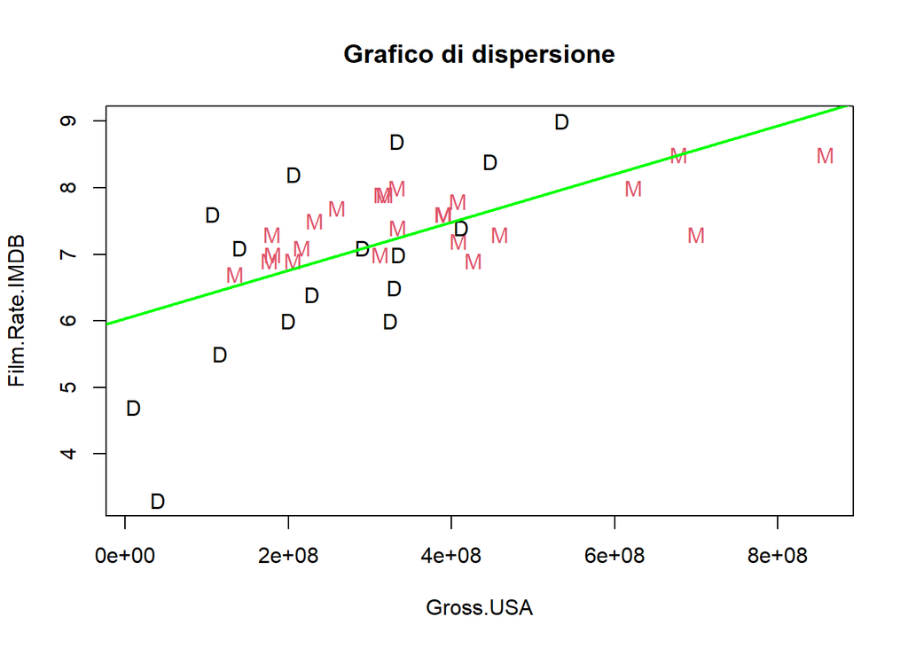

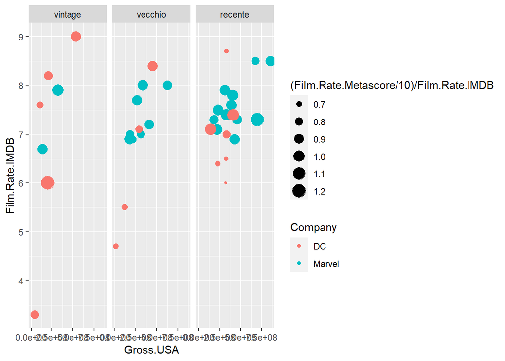

### *Verifico la correlazione tra la variabile Gross.USA e Opening.weekend.USA, realizzando il grafico di dispersione.*

```
                    Opening.Weekend.USA Gross.USA
Opening.Weekend.USA           1.0000000 0.9357828
Gross.USA                     0.9357828 1.0000000
```

```
Call:
lm(formula = Opening.weekend.USA ~ Gross.USA)

Residuals:
      Min        1Q    Median        3Q       Max
-51430701 -14606526   2173182  12605105  51728565

Coefficients:
             Estimate Std. Error t value Pr(>|t|)
(Intercept) 1.609e+05  8.132e+06    0.02    0.984
Gross.USA   3.556e-01  2.203e-02   16.14   <2e-16 ***
---
Signif. codes:  0 '***' 0.001 '**' 0.01 '*' 0.05 '.' 0.1 ' ' 1

Residual standard error: 24540000 on 37 degrees of freedom
Multiple R-squared:  0.8757,    Adjusted R-squared:  0.8723
F-statistic: 260.6 on 1 and 37 DF,  p-value: < 2.2e-16
```

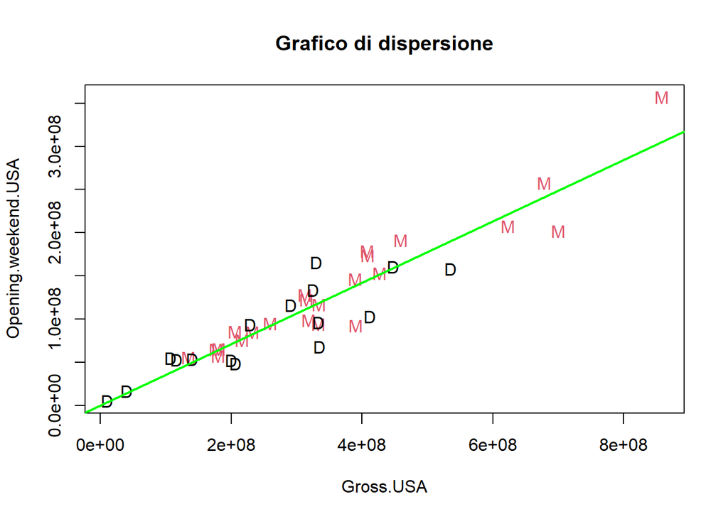

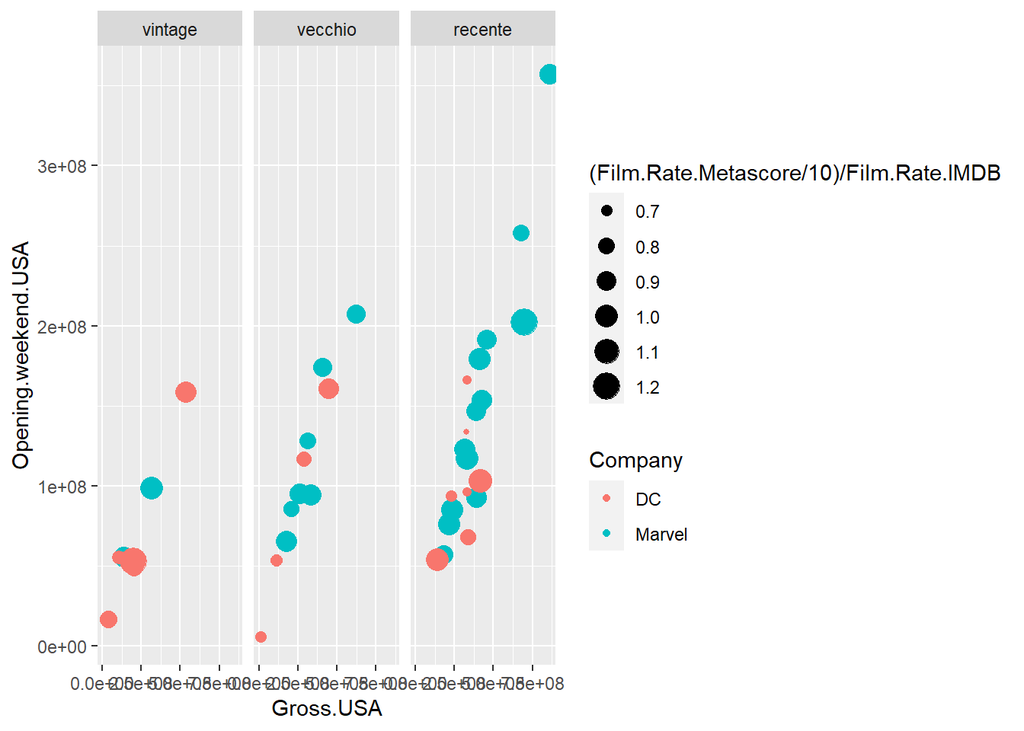

## **VARIABILE GROSS.WORLD**

### *Analizzo il summary della variabile Gross.World per dedurre il range di valori che assume*

```r
MCU_vs_DCU.df[,11]
```

```
 [1]  585366247  263427551  623933331  449326618  370569774 1518812988
 [7] 1214811252  644783140  714421503  772776600 1402805868  519311965
[13] 1153296293  677718395  863756051  880166924  853977126 1346913161
[19] 2048359754  622674139 1128274794 2797800564 1131927996   82102379
[25]  373413297  391081192 1004934033  185258983   10903312  219851172
[31] 1081041287  668045518  873634919  746846894  821847012  657924295
[37] 1148161807  364571656 1060504580
```

```r
Gross.World=MCU_vs_DCU.df[,11]
summary(Gross.World)
```

```
     Min.   1st Qu.    Median      Mean   3rd Qu.      Max.
1.090e+07 4.843e+08 7.468e+08 8.276e+08 1.105e+09 2.798e+09
```

### *Analizzo il summary della variabile Gross.World categorizzata in base alla variabile Company per dedurre il range di valori che assume.*

#### Marvel

```
     Min.   1st Qu.    Median      Mean   3rd Qu.      Max.
2.634e+08 6.233e+08 8.540e+08 9.820e+08 1.184e+09 2.798e+09
```

#### DC

```
     Min.   1st Qu.    Median      Mean   3rd Qu.      Max.
1.090e+07 3.284e+08 6.630e+08 6.056e+08 9.065e+08 1.148e+09
```

### *Creiamo ,quindi, boxplot e istogrammi che ci facciano intuire in maniera piu chiara la distribuzione della variabile Gross.World generica e relativamente ai film Marvel DC.*

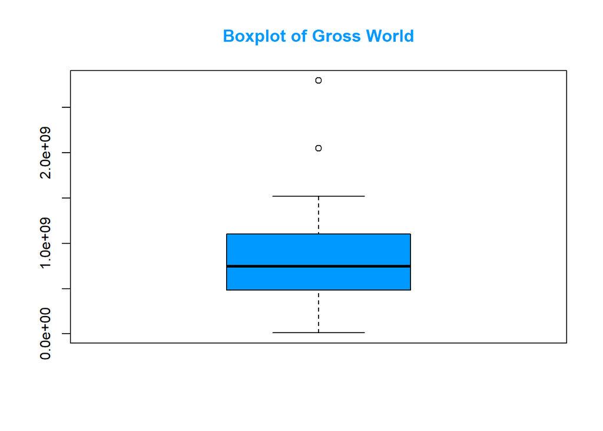

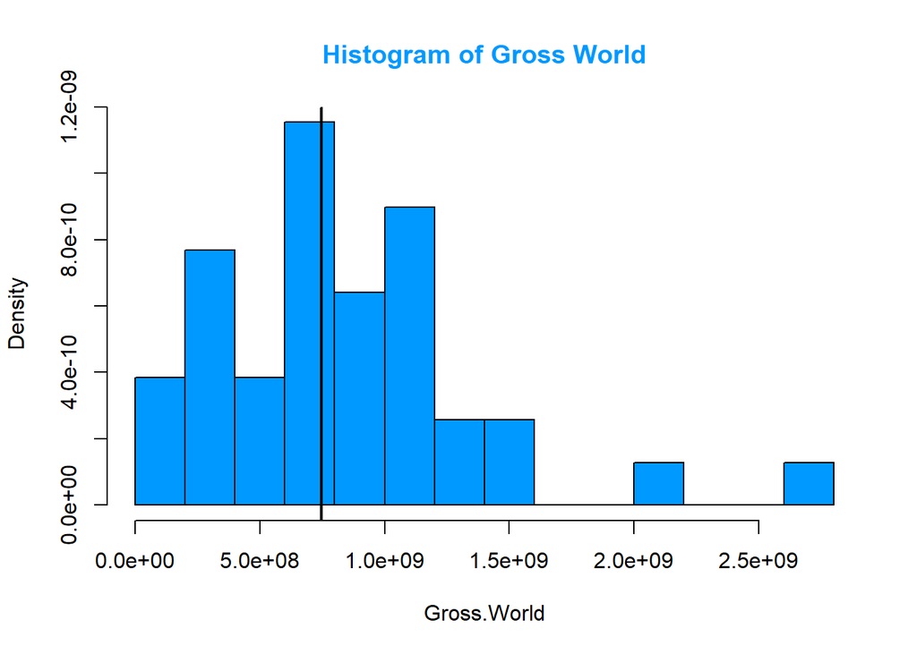

[figure not shown]

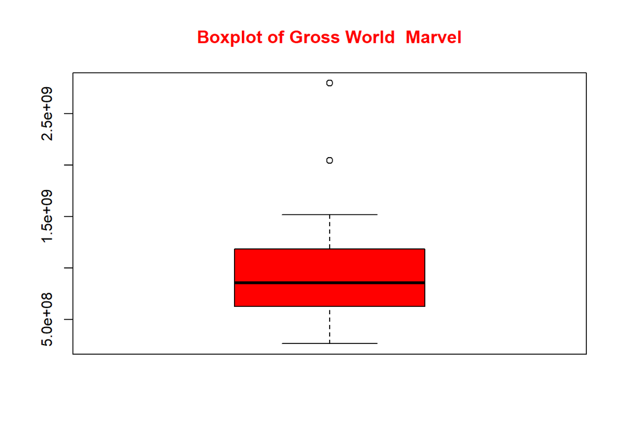

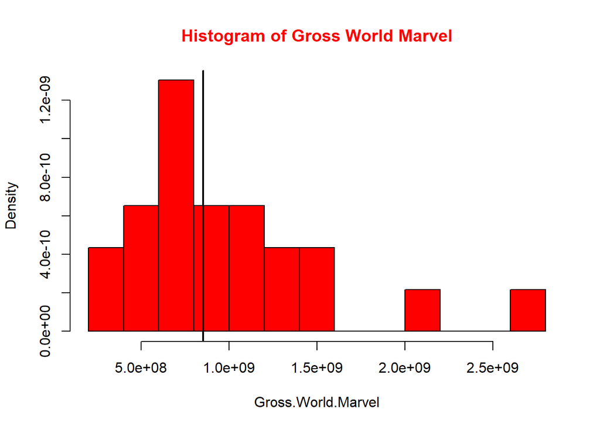

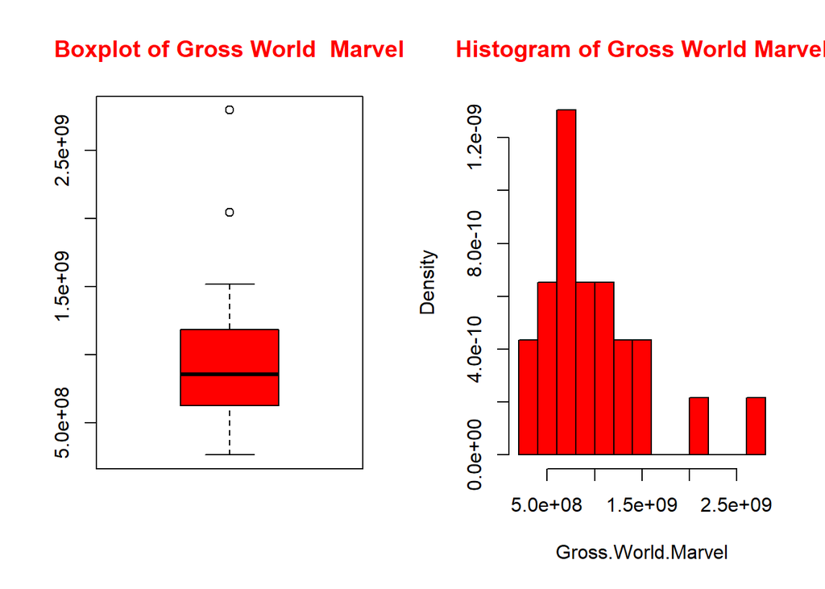

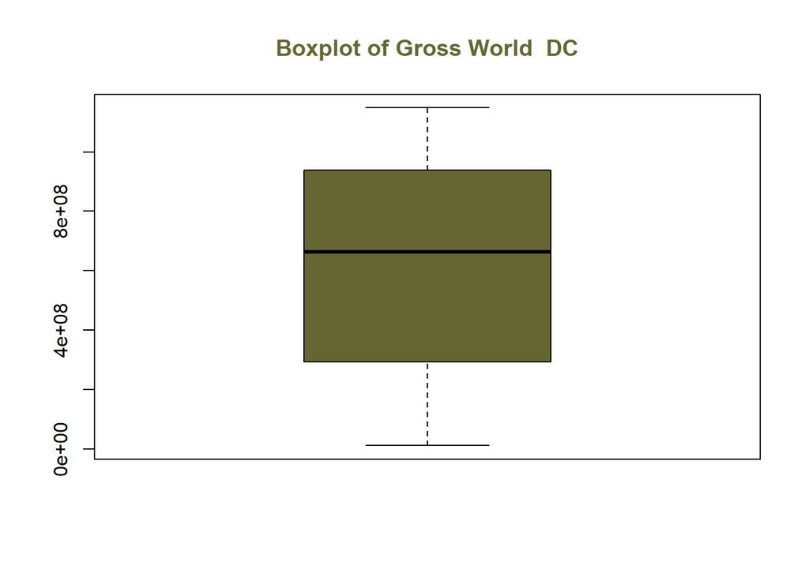

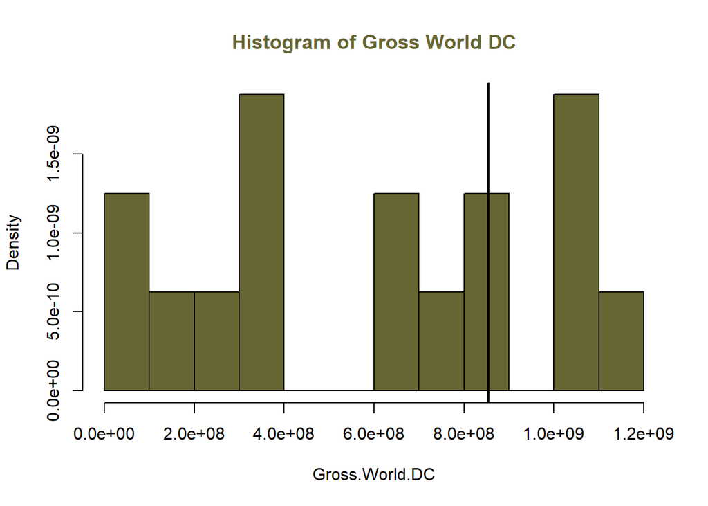

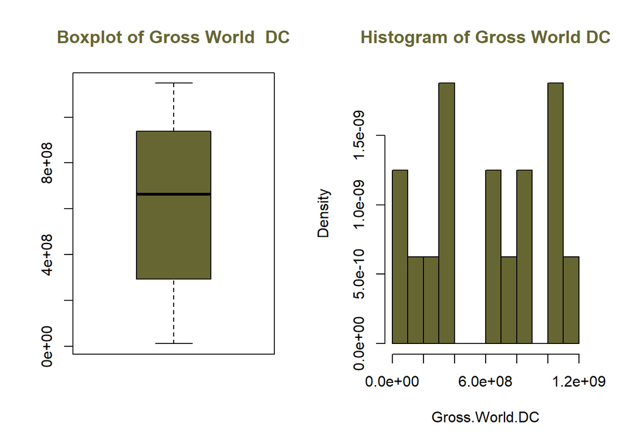

#### *E’ difficile confrontare boxplot e istogrammi che si distribuiscono su scale differenti.*

### *E’ necessario affiancare i boxplot della variabile Gross.World di Marvel e DC, in modo da valutare la distribuzione avendo come riferimento la stessa scala*

```
$DC
     Min.   1st Qu.    Median      Mean   3rd Qu.      Max.
1.090e+07 3.284e+08 6.630e+08 6.056e+08 9.065e+08 1.148e+09

$Marvel
     Min.   1st Qu.    Median      Mean   3rd Qu.      Max.
2.634e+08 6.233e+08 8.540e+08 9.820e+08 1.184e+09 2.798e+09
```

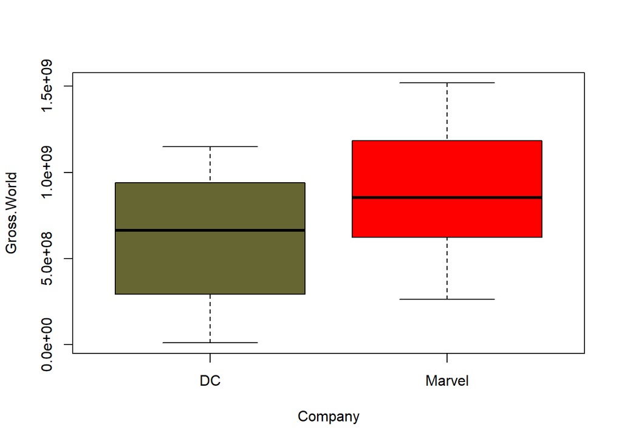

#### *Noto che le osservazioni della variabile Gross.World si distribuiscono in maniera differente:*

#### -I minimi ed i massimi dei due boxplot presentano disguaglianza:

> Le osservazioni di questa variabile seguono quelle della variabile precedentemente analizzata: il massimo valore della variabile Gross.USA relativa alla company Marvel è maggiore rispetto a quello DC. Il minimo valore ,invece, appartiene sempre ad un film DC.

#### -Il primo quartile ed il terzo presentano una netta disparità:

> La maggior parte delle osservazioni Marvel ha ottenuto maggior Gross nel mondo rispetto a quelle DC.

```
$DC
     Min.   1st Qu.    Median      Mean   3rd Qu.      Max.
  5379365  53014501  80857880  86378724 120885084 166007347

$Marvel
     Min.   1st Qu.    Median      Mean   3rd Qu.      Max.
 55414050  85398076 117027503 135096585 176641864 357115007
```

```
$DC
     Min.   1st Qu.    Median      Mean   3rd Qu.      Max.
 10547117 134429035 260034906 253868671 333668887 535234033

$Marvel
     Min.   1st Qu.    Median      Mean   3rd Qu.      Max.
134806913 224645330 333176600 371542272 417921916 858373000
```

```
$DC
     Min.   1st Qu.    Median      Mean   3rd Qu.      Max.
1.090e+07 3.284e+08 6.630e+08 6.056e+08 9.065e+08 1.148e+09

$Marvel
     Min.   1st Qu.    Median      Mean   3rd Qu.      Max.
2.634e+08 6.233e+08 8.540e+08 9.820e+08 1.184e+09 2.798e+09
```

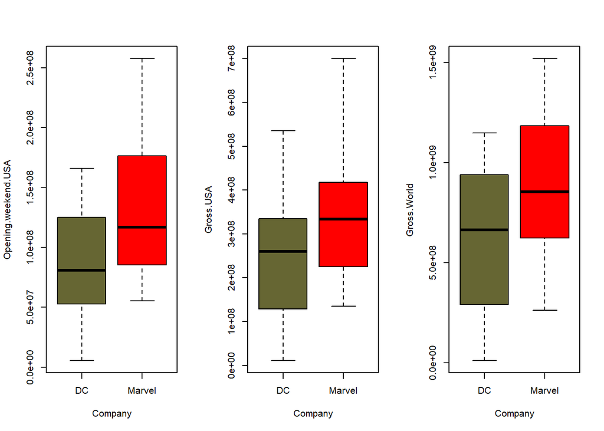

### *Creo un istorgamma che metta in relazione la variabile Gross.World e la variabile Company*

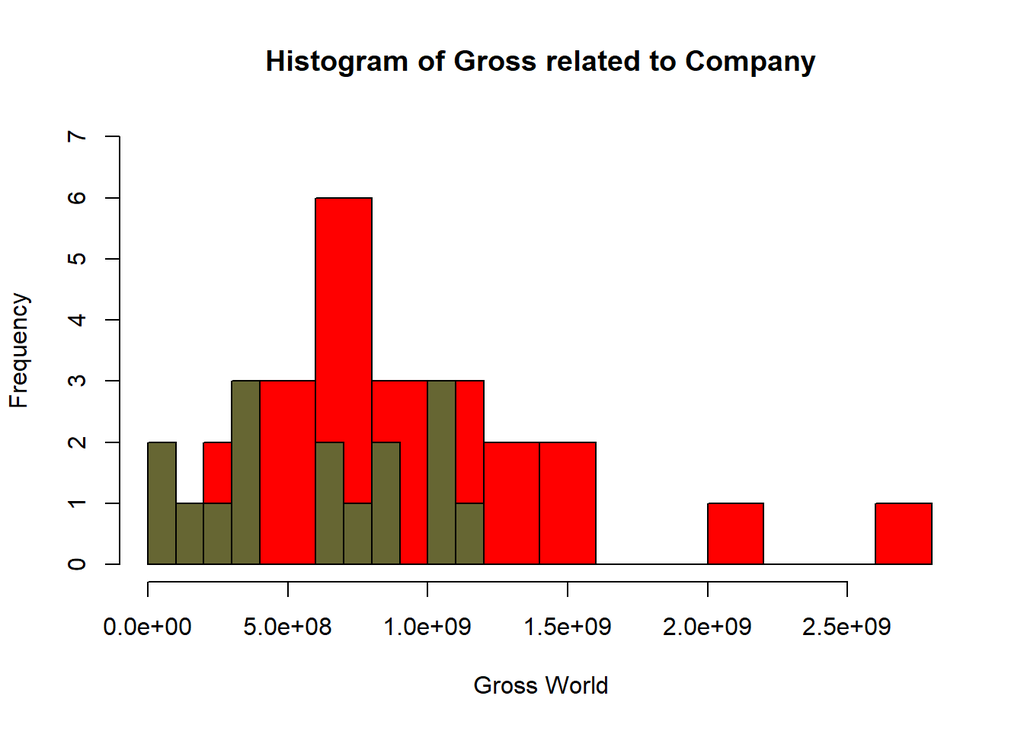

### *Misuro quindi la connessione che c’è tra l’appartenenza ad una determinata casa cinematografica ed il profitto realizzato nel mondo da un determinato film*

```r
aov.Gross.World=summary(aov(Gross.World~Company))

dev.Gross.World=aov.Gross.World[[1]]$`Sum Sq`

eta.quadro.Gross.World=dev.Gross.World[1]/sum(dev.Gross.World)
eta.quadro.Gross.World
```

```
[1] 0.1236837
```

#### *Si deduce che la dipendenza in media dalla variabile Company spiega solo il 12.3% della variabilità totale della variabile Gross.World*

### *Quale film ha avuto incasso più basso? Quale il più alto?*

```
     Min.   1st Qu.    Median      Mean   3rd Qu.      Max.
1.090e+07 4.843e+08 7.468e+08 8.276e+08 1.105e+09 2.798e+09
```

```
[1] "Jonah Hex"
```

```
[1] "DC"
```

```
[1] "Avengers: Endgame"
```

```
[1] "Marvel"
```

### *Quanto ha incassato Marvel dalle uscite di tutti i suoi film nel mondo?*

```
[1] 22585212034
```

### *Quanto ha incassato DC dalle uscite di tutti i suoi film nel mondo?*

```
[1] 9690122336
```

### *Quanto ha incassato il primo film Marvel ed il primo film DC?*

```
[1] 585366247 263427551
```

```
[1] 82102379
```

```
                     Rate Gross.Worldwide
Rate            1.0000000       0.5653478
Gross.Worldwide 0.5653478       1.0000000
```

```
Call:
lm(formula = Film.Rate.IMDB ~ Gross.World)

Residuals:
    Min      1Q  Median      3Q     Max
-3.0532 -0.5629  0.1309  0.4584  1.5953

Coefficients:
             Estimate Std. Error t value Pr(>|t|)
(Intercept) 6.260e+00  2.681e-01  23.352  < 2e-16 ***
Gross.World 1.139e-09  2.733e-10   4.169 0.000177 ***
---
Signif. codes:  0 '***' 0.001 '**' 0.01 '*' 0.05 '.' 0.1 ' ' 1

Residual standard error: 0.8984 on 37 degrees of freedom
Multiple R-squared:  0.3196,    Adjusted R-squared:  0.3012
F-statistic: 17.38 on 1 and 37 DF,  p-value: 0.0001767
```

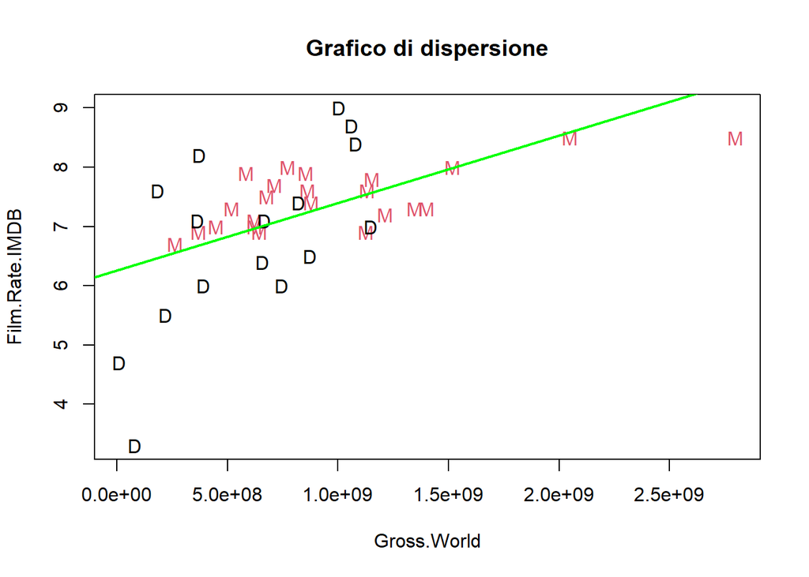

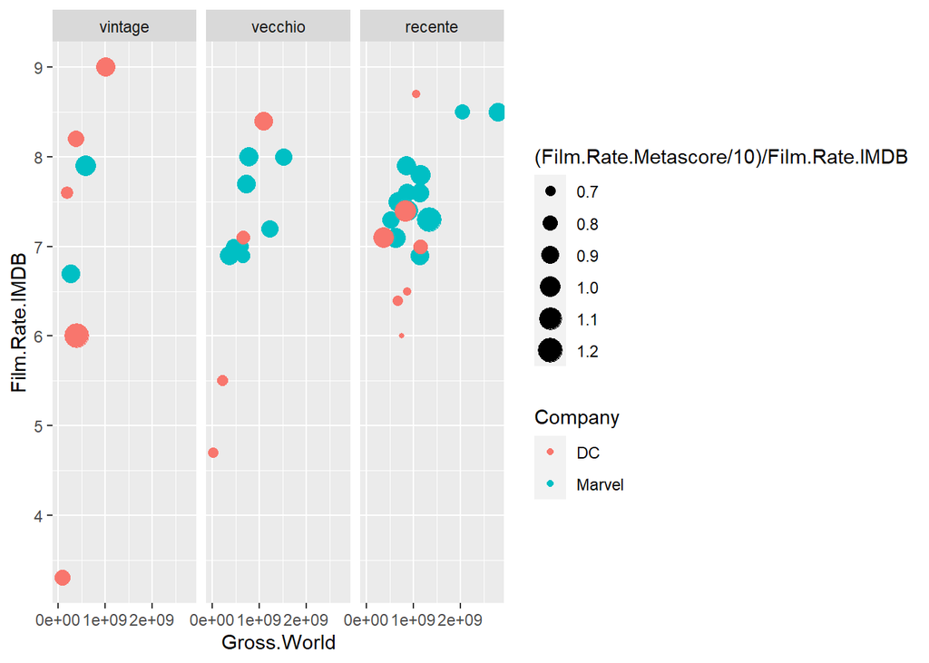

#### *Si nota,quindi, che la correlazione tra Film.Rate.IMDB E Gross.World è abbastanza alta, pertanto mi vuol dire quanto è forte il legame simmetrico tra Film.Rate.IMDB e Gross.World quando sono paritarie.*

### *Verifico la correlazione tra la variabile Gross.World e Opening.weekend.USA, realizzando il grafico di dispersione.*

```
                    Opening.Weekend.USA Gross.Worldwide
Opening.Weekend.USA           1.0000000       0.9330748
Gross.Worldwide               0.9330748       1.0000000
```

```
Call:
lm(formula = Opening.weekend.USA ~ Gross.World)

Residuals:
      Min        1Q    Median        3Q       Max
-85757267 -10648750   2192197  13966596  45362877

Coefficients:
             Estimate Std. Error t value Pr(>|t|)
(Intercept) 1.567e+07  7.468e+06   2.098   0.0428 *
Gross.World 1.202e-01  7.615e-03  15.780   <2e-16 ***
---
Signif. codes:  0 '***' 0.001 '**' 0.01 '*' 0.05 '.' 0.1 ' ' 1

Residual standard error: 25030000 on 37 degrees of freedom
Multiple R-squared:  0.8706,    Adjusted R-squared:  0.8671
F-statistic:   249 on 1 and 37 DF,  p-value: < 2.2e-16
```

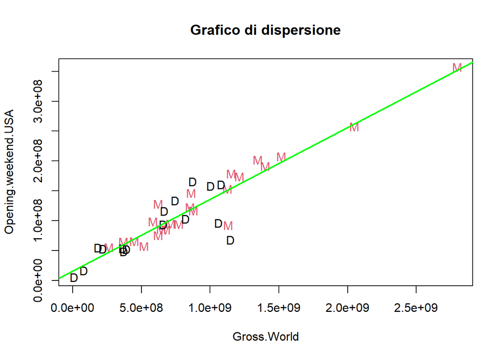

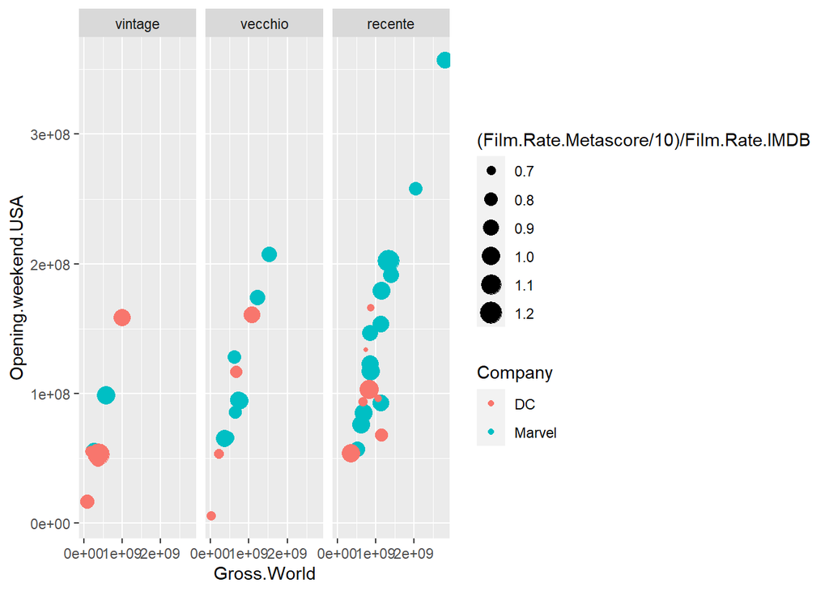

#### *Si nota,quindi, che la correlazione tra Opening.weekend.USA E Gross.World è altissima, pertanto mi vuol dire quanto è forte il legame simmetrico tra Opening.weekend.USA e Gross.World quando sono paritarie*

### *Verifico la correlazione tra la variabile Gross.World e Gross.USA, realizzando il grafico di dispersione.*

```
                Gross.USA Gross.Worldwide
Gross.USA       1.0000000       0.9396769
Gross.Worldwide 0.9396769       1.0000000
```

```
Call:
lm(formula = Gross.USA ~ Gross.World)

Residuals:
      Min        1Q    Median        3Q       Max
-92312033 -40792169 -13135826  27450873 211409655

Coefficients:
             Estimate Std. Error t value Pr(>|t|)
(Intercept) 5.973e+07  1.869e+07   3.195  0.00285 **
Gross.World 3.185e-01  1.906e-02  16.710  < 2e-16 ***
---
Signif. codes:  0 '***' 0.001 '**' 0.01 '*' 0.05 '.' 0.1 ' ' 1

Residual standard error: 62640000 on 37 degrees of freedom
Multiple R-squared:  0.883, Adjusted R-squared:  0.8798
F-statistic: 279.2 on 1 and 37 DF,  p-value: < 2.2e-16
```

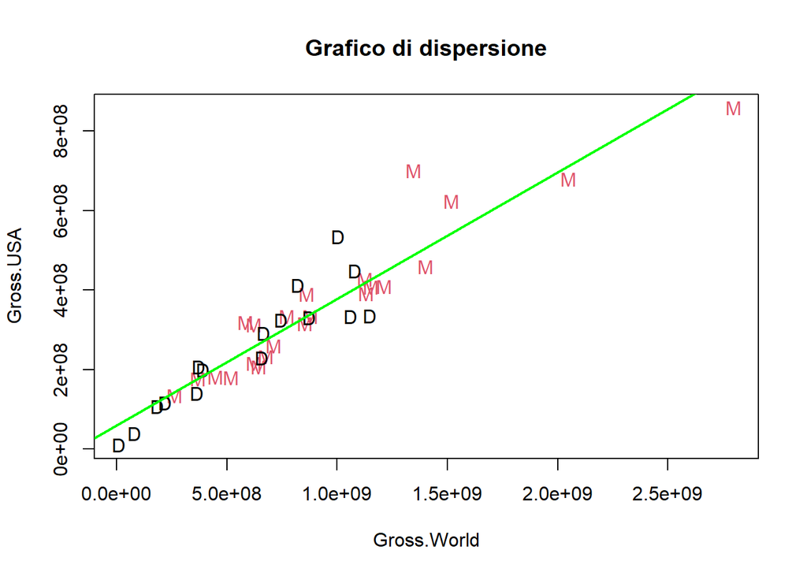

#### *Si nota,quindi, che la correlazione tra Gross.USA E Gross.World è altissima, pertanto mi vuol dire quanto è forte il legame simmetrico tra Gross.USA e Gross.World quando sono paritarie.*

### *Realizzo il grafico degli andamenti dei profitti nel mondo categorizzati per casa cinematografica e per anno di uscita.*

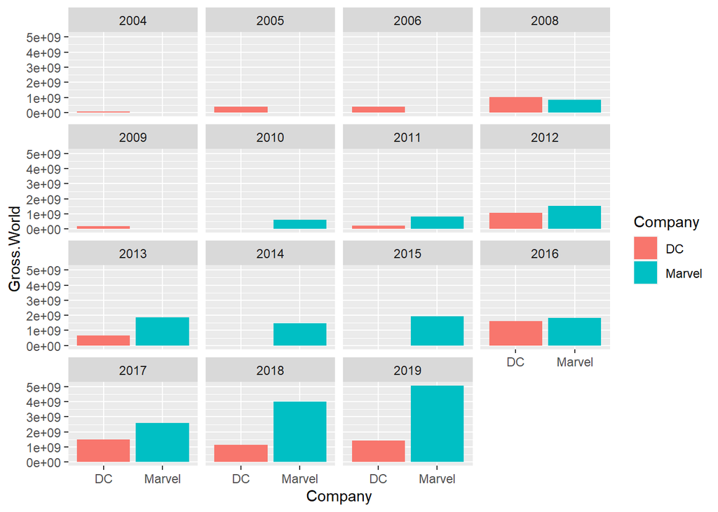